# Assignment 2

#### 1.)

To investigate the influence of temperature and humidity on this process, the time to decay was measured for 18 slices of white bread, which were placed in 3 different environments and humidified or not. The data are given in the file bread.txt, with the first column time to decay in hours, the second column the environment (cold, warm or intermediate temperature) and the third column the humidity.

```r
bread = read.table("bread.txt",header=TRUE)
bread$humidity = as.factor(bread$humidity)
bread$environment = as.factor(bread$environment);attach(bread)
head(bread,3)
```

A data.frame: 3 × 3

|  | hours <int> | environment <fct> | humidity <fct> |
| --- | --- | --- | --- |
| 1 | 360 | cold | dry |
| 2 | 360 | cold | dry |
| 3 | 372 | cold | dry |

- $n=18$ total observations, $I=3$ levels of factor A (env), $J=2$ levels of factor B (hum), i.e $N = \frac{n}{I\times J} = \frac{18}{3\times 2} = 3$ obervations per combination.

a) The 18 slices came from a single loaf, but were randomized to the 6 combinations of conditions. Present an R-code for this randomization process.

```r
I=3; J=2; N=3
rbind(rep(1:I,each=N*J),rep(1:J,N*I),sample(1:(N*I*J)))
```

A matrix: 3 × 18 of type int

| 1 | 1 | 1 | 1 | 1 | 1 | 2 | 2 | 2 | 2 | 2 | 2 | 3 | 3 | 3 | 3 | 3 | 3 |
| --- | --- | --- | --- | --- | --- | --- | --- | --- | --- | --- | --- | --- | --- | --- | --- | --- | --- |
| 1 | 2 | 1 | 2 | 1 | 2 | 1 | 2 | 1 | 2 | 1 | 2 | 1 | 2 | 1 | 2 | 1 | 2 |
| 7 | 13 | 9 | 1 | 14 | 8 | 15 | 18 | 3 | 11 | 12 | 6 | 4 | 10 | 16 | 5 | 17 | 2 |

b) Make two boxplots of hours versus the two factors and two interaction plots (keeping the two factors fixed in turn)

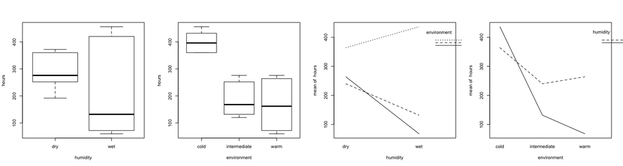

```r
par(mfrow=c(1,4));options(repr.plot.width=15, repr.plot.height=4)
boxplot(hours~humidity);boxplot(hours~environment);
interaction.plot(humidity,environment,hours);interaction.plot(environment,humidity,hours);
```

We can expect significant interactions, since the non-parallelity connot be only due to noise.

c)Perform an analysis of variance to test for effect of the factors temperature, humidity, and their interaction. Describe the interaction effect in words.

```r
model = lm(hours~humidity*environment)
round(drop1(model, test="F"),3)
```

A anova: 2 × 6

|  | Df <dbl> | Sum of Sq <dbl> | RSS <dbl> | AIC <dbl> | F value <dbl> | Pr(>F) <dbl> |
| --- | --- | --- | --- | --- | --- | --- |
| <none> | NA | NA | 5184 | 113.933 | NA | NA |
| humidity:environment | 2 | 55984 | 61168 | 154.358 | 64.796 | 0 |

Testing $H0 : \gamma_{i,j} = 0 \ \forall \ (i,j)$ has a very small p-value (=rejected) so we can say that there is significant evidence for interaction. As an example, for warm and intermediate environments, wet humidites will *decrease* the mean hours, while for a cold environment, a wet humidity will actaully increase the hours.

For testing the two factors specifically, we use the additive model (Since the design is balanced, we dont need to worry about formulae order).

```r
model2 = lm(hours~humidity+environment);
round(drop1(model2,test="F"),3)
```

A anova: 3 × 6

|  | Df <dbl> | Sum of Sq <dbl> | RSS <dbl> | AIC <dbl> | F value <dbl> | Pr(>F) <dbl> |
| --- | --- | --- | --- | --- | --- | --- |
| <none> | NA | NA | 61168 | 154.358 | NA | NA |
| humidity | 1 | 26912 | 88080 | 158.921 | 6.160 | 0.026 |
| environment | 2 | 201904 | 263072 | 176.617 | 23.106 | 0.000 |

```r
summary(model2)$coefficients
```

A matrix: 4 × 4 of type dbl

|  | Estimate | Std. Error | t value | Pr(>\|t\|) |
| --- | --- | --- | --- | --- |
| (Intercept) | 438.66667 | 31.15960 | 14.078059 | 1.174482e-09 |
| humiditywet | -77.33333 | 31.15960 | -2.481846 | 2.637500e-02 |
| environmentintermediate | -214.00000 | 38.16256 | -5.607590 | 6.458901e-05 |
| environmentwarm | -234.00000 | 38.16256 | -6.131664 | 2.598550e-05 |

d.) Which of the two factors has the greatest (numerical) influence on the decay? Is this a good question?

According to the output of the additive anova, environment has a greater effect than humidity. The question may not be too interesting considering the significant interactions and it's influence on the response. A better question might be which combination has the strongest effect. Looking at single factors and determining its numerical effect without treating interactions will yield unreasonable results.

e)

Check the model assumptions by using relevant diagnostic tools. Are there any outliers?

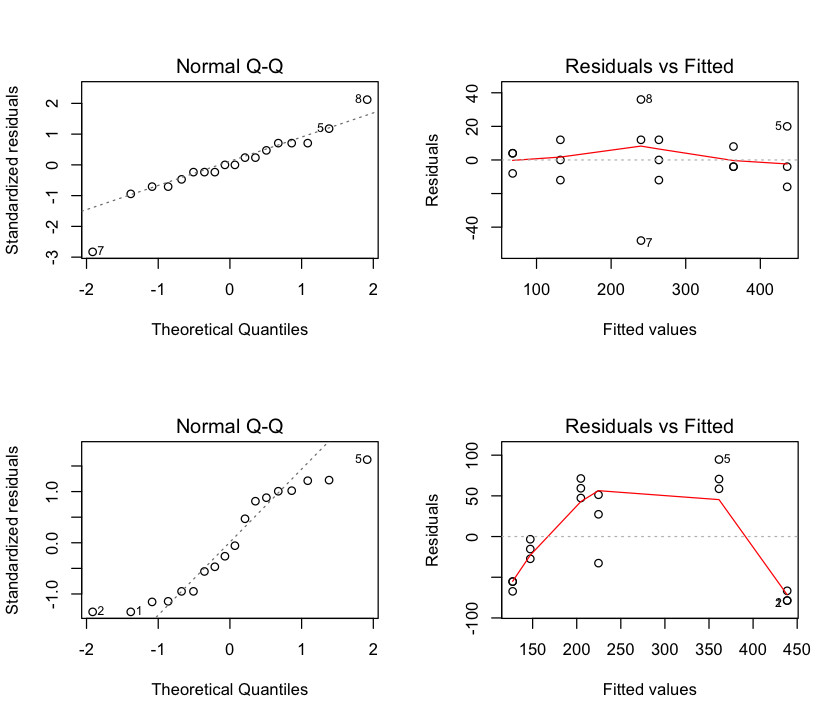

```r
par(mfrow=c(2,2));options(repr.plot.width=7, repr.plot.height=6)
plot(model,2);plot(model,1);plot(model2,2);plot(model2,1);
```

- Observation 5 with combination (cold/wet) is an outlier
- Observation 8 with combination (intermediate/dry) is an outlier

$M_0$ : For the model which includes the interactions (upper two plots), the distribution of the residuals look reasonable, while the QQplot indicates that normality is doubtful. \ $M_1$ : Both normality and homoscedasticity of residuals are doubtful for the additive model (two plots on the bottom)

#### 2.)

```r
df = read.table("search.txt",header=TRUE)
df$skill = as.factor(df$skill)
df$interface = as.factor(df$interface);attach(df)
head(df,2)
```

A data.frame: 2 × 3

|  | time <dbl> | skill <fct> | interface <fct> |
| --- | --- | --- | --- |
| 1 | 16.1 | 1 | 1 |
| 2 | 14.5 | 2 | 1 |

a.)

- $n=15$ subjects, blocking factor with $B=5$ levels, treatment factor with $I=3$ levels,$N=\frac{n}{B \times I}=\frac{15}{5 \times 3} = 1$ observation per cell.

```r
I=3; B=5; N=1
for(b in 1:B){print(sample((I*N)))}
```

```
[1] 3 2 1
[1] 2 1 3
[1] 2 3 1
[1] 3 2 1
[1] 1 3 2
```

Each printed line represents a level of the blocking factor. (rows indexed with $b$)

b)

Test the null hypothesis that the search time is the same for all interfaces. What type of interface does require the longest search time? For which combination of skill level and type of interface is the search time the shortest? Estimate the time it takes a typical user of skill level 3 to find the product on the website if the website uses interface 3.

First we check $H_0 : \alpha_1 = \alpha_2 = \alpha_3 = 0$, but prior to that we have a look at the data.

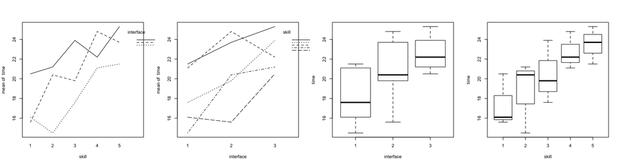

```r
par(mfrow=c(1,4));options(repr.plot.width=15, repr.plot.height=4)
interaction.plot(skill, interface,time);interaction.plot(interface, skill, time);
boxplot(time~interface);boxplot(time~skill);
```

```r
model = lm(time~interface+skill);
drop1(model, test="F")
```

A anova: 3 × 6

|  | Df <dbl> | Sum of Sq <dbl> | RSS <dbl> | AIC <dbl> | F value <dbl> | Pr(>F) <dbl> |
| --- | --- | --- | --- | --- | --- | --- |
| <none> | NA | NA | 25.80133 | 22.13564 | NA | NA |
| interface | 2 | 50.46533 | 76.26667 | 34.39279 | 7.823678 | 0.01309874 |
| skill | 4 | 80.05067 | 105.85200 | 35.30988 | 6.205157 | 0.01420818 |

Using an ordinary additive factorial analysis, treatment effects are significantly different from 0 (i.e their beta estimates). $H_0$ needs to be rejected.

```r
print(round(summary(model)$coefficients,4))
```

```
            Estimate Std. Error t value Pr(>|t|)
(Intercept)  15.0133     1.2268 12.2376   0.0000
interface2    2.7000     1.1358  2.3772   0.0447
interface3    4.4600     1.1358  3.9267   0.0044
skill2        1.3000     1.4663  0.8866   0.4012
skill3        3.0333     1.4663  2.0687   0.0724
skill4        5.3000     1.4663  3.6145   0.0068
skill5        6.1000     1.4663  4.1601   0.0032
```

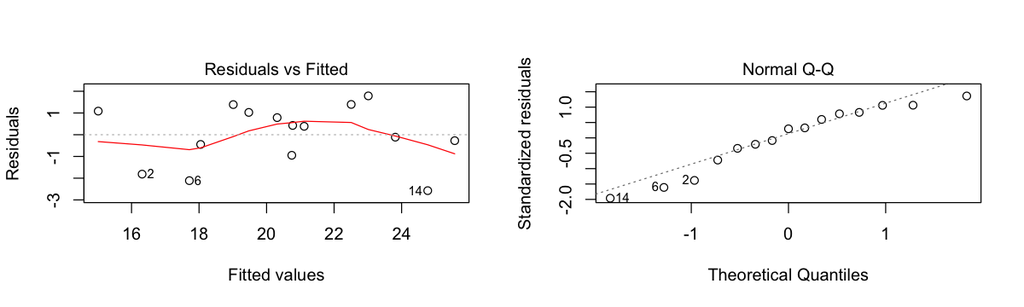

```r
par(mfrow=c(1,2));options(repr.plot.width=10, repr.plot.height=3)
plot(model,1); plot(model, 2)
```

The normality assumption is definetely not a perfect fit here, normality is doubtful. Distribution of residuals should be homogenous around 0 with no pattern, which is somewhat reasonable here, although there are minor negative outliers (skewed towards lower values).

d) Perform the Friedman test to test whether there is an effect of interface.

```r
friedman.test(y=time,groups=interface,blocks=skill)
```

```
	Friedman rank sum test

data:  time, interface and skill
Friedman chi-squared = 6.4, df = 2, p-value = 0.04076
```

The friedman test (the rank-based alternative to ANOVA) tests the null hypothesis that apart from an effect of blocks, the location parameter of y is the same in each of the groups. $H_0 : \alpha_1 = \alpha_2 = \alpha_3 = 0$ is therefore rejected ($p = 0.04076$).

e)

Test the null hypothesis that the search time is the same for all interfaces by a one-wayANOVA test, ignoring the variable skill. Is it right/wrong or useful/not useful to perform this test on this dataset?

```r
bad_model = lm(time~interface);anova(bad_model)
```

A anova: 2 × 5

|  | Df <int> | Sum Sq <dbl> | Mean Sq <dbl> | F value <dbl> | Pr(>F) <dbl> |
| --- | --- | --- | --- | --- | --- |
| interface | 2 | 50.46533 | 25.23267 | 2.860522 | 0.09641655 |
| Residuals | 12 | 105.85200 | 8.82100 | NA | NA |

```r
summary(bad_model)$coefficients#BIASED
```

A matrix: 3 × 4 of type dbl

|  | Estimate | Std. Error | t value | Pr(>\|t\|) |
| --- | --- | --- | --- | --- |
| (Intercept) | 18.16 | 1.328232 | 13.672311 | 1.116114e-08 |
| interface2 | 2.70 | 1.878404 | 1.437391 | 1.761675e-01 |
| interface3 | 4.46 | 1.878404 | 2.374357 | 3.512183e-02 |

If we simply omit the blocking factor, the linear model will incorporate any variance which is produced by the blocking factor into the treatment factor. This will give false estimates since now the treatment factors incorporate variance that does not belong to it. By using a blocking factor we can explain parts of the variance by this blocking factor, which ultimatively allows us to make more precise conclusions about the factor of itnerest.

#### 3.)

```r
df = read.table("cow.txt",header=TRUE)
df$treatment = as.factor(df$treatment)
df$order = as.factor(df$order)
df$id = as.factor(df$id)
df$per = as.factor(df$per);attach(df)
```

```r
head(df,3)
```

A data.frame: 3 × 5

|  | treatment <fct> | order <fct> | id <fct> | milk <dbl> | per <fct> |
| --- | --- | --- | --- | --- | --- |
| 1 | A | AB | 1 | 29.9 | 1 |
| 2 | B | AB | 1 | 27.8 | 2 |
| 3 | A | AB | 2 | 54.0 | 1 |

a) Test whether the type of feedingstuffs influences milk production using an ordinary “fixed effects” model, fitted with lm. Estimate the difference in milk production.

There are $N=9$ cows. There $n=2*N=18$ measurements. There are two periods $p$ (=potential sequence effect)

```r
model_fe = lm(milk~id+per+treatment);
drop1(model_fe, test="F")
```

A anova: 4 × 6

|  | Df <dbl> | Sum of Sq <dbl> | RSS <dbl> | AIC <dbl> | F value <dbl> | Pr(>F) <dbl> |
| --- | --- | --- | --- | --- | --- | --- |
| <none> | NA | NA | 17.34400 | 21.33175 | NA | NA |
| id | 8 | 2467.47111 | 2484.81511 | 94.69647 | 124.483235 | 7.494454e-07 |
| per | 1 | 25.38711 | 42.73111 | 35.56200 | 10.246182 | 1.504561e-02 |
| treatment | 1 | 1.15600 | 18.50000 | 20.49318 | 0.466559 | 5.165364e-01 |

```r
print(round(summary(model_fe)$coefficients,3))
```

```
            Estimate Std. Error t value Pr(>|t|)
(Intercept)    30.30      1.244  24.349    0.000
id2            23.00      1.574  14.612    0.000
id3            11.15      1.574   7.084    0.000
id4            -1.35      1.574  -0.858    0.419
id5            -7.05      1.574  -4.479    0.003
id6            23.45      1.574  14.898    0.000
id7            13.55      1.574   8.608    0.000
id8             4.90      1.574   3.113    0.017
id9           -11.20      1.574  -7.115    0.000
per2           -2.39      0.747  -3.201    0.015
treatmentB     -0.51      0.747  -0.683    0.517
```

- In the FE model, treatment B yields 0.51 less than A.
- treatment effect is not significant.
- The period effect is significant
- The design of fixed effects is not appropiate since ANOVA is treating the block and treatment factors equally. - Since we can apriori know what is blocking and interesting, we need to treat the estimation differently

b) Repeat a) and b) by performing a mixed effects analysis, modelling the cow effect as a random effect (use the function lmer). Compare your results to the results found by using a fixed effects model. (You will need to install the R-package lme4, which is not included in the standard distribution of R.)

```r
library(lme4)
me_model_full = lmer(milk~treatment+order+per+(1|id),REML=FALSE);
summary(me_model_full)
```

```
Linear mixed model fit by maximum likelihood  ['lmerMod']
Formula: milk ~ treatment + order + per + (1 | id)

     AIC      BIC   logLik deviance df.resid
   119.3    124.7    -53.7    107.3       12

Scaled residuals:
     Min       1Q   Median       3Q      Max
-1.53111 -0.37104  0.02686  0.26747  1.72489

Random effects:
 Groups   Name        Variance Std.Dev.
 id       (Intercept) 133.145  11.539
 Residual               1.927   1.388
Number of obs: 18, groups:  id, 9

Fixed effects:
            Estimate Std. Error t value
(Intercept)  38.5000     5.8110   6.625
treatmentB   -0.5100     0.6585  -0.775
orderBA      -3.4700     7.7685  -0.447
per2         -2.3900     0.6585  -3.630

Correlation of Fixed Effects:
           (Intr) trtmnB ordrBA
treatmentB -0.063
orderBA    -0.743  0.000
per2       -0.063  0.111  0.000
```

Using a random effects model we essentially assume that the blocks (here cows) are not fixed and therefore limited to the sample, but rather randomly drawn from a distribution of cows, the block population. The full model yields a block population estimate of $\mathcal{N}(0, 133.145)$ (individual effects) Estimated treatment and period effects stay the same as in fixed effects.

Refitting a reduced model (without treatment) and comparing it to the full model will give us the actual treatment effect.

```r
me_model_full = lmer(milk~treatment+order+per+(1|id),REML=FALSE);
me_model_reduced = lmer(milk~order+per+(1|id),REML=FALSE)
anova(me_model_full, me_model_reduced)
```

A anova: 2 × 8

|  | npar <dbl> | AIC <dbl> | BIC <dbl> | logLik <dbl> | deviance <dbl> | Chisq <dbl> | Df <dbl> | Pr(>Chisq) <dbl> |
| --- | --- | --- | --- | --- | --- | --- | --- | --- |
| me_model_reduced | 5 | 117.8929 | 122.3447 | -53.94644 | 107.8929 | NA | NA | NA |
| me_model_full | 6 | 119.3122 | 124.6544 | -53.65608 | 107.3122 | 0.580717 | 1 | 0.4460314 |

Comparing both models yields the indication that the treatment factor does not have a significant effect, since $H_0$ cannot be rejected. Essentially this means that the larger model does not add much "explanatory power" (i.e explained variance) to the reduced model. If we compare that with the outcome of the fixed effects model, we get the same conclusion.

- In mixed effectes models, also conclusion about order is possible

c.)

```r
head(df)
```

A data.frame: 6 × 5

|  | treatment <fct> | order <fct> | id <fct> | milk <dbl> | per <fct> |
| --- | --- | --- | --- | --- | --- |
| 1 | A | AB | 1 | 29.9 | 1 |
| 2 | B | AB | 1 | 27.8 | 2 |
| 3 | A | AB | 2 | 54.0 | 1 |
| 4 | B | AB | 2 | 49.7 | 2 |
| 5 | A | AB | 3 | 41.6 | 1 |
| 6 | B | AB | 3 | 38.4 | 2 |

```r
t.test(milk[treatment=="A"], milk[treatment=="B"], paired=TRUE)
```

```
	Paired t-test

data:  milk[treatment == "A"] and milk[treatment == "B"]
t = 0.22437, df = 8, p-value = 0.8281
alternative hypothesis: true difference in means is not equal to 0
95 percent confidence interval:
 -2.267910  2.756799
sample estimates:
mean of the differences
              0.2444444
```

- The periods significant effect cannot be ignored, thus t-test is inappropiate.

#### 4.)

```r
words = data.matrix(read.table("austen.txt",header=TRUE))
words
```

A matrix: 6 × 4 of type int

|  | Sense | Emma | Sand1 | Sand2 |
| --- | --- | --- | --- | --- |
| a | 147 | 186 | 101 | 83 |
| an | 25 | 26 | 11 | 29 |
| this | 32 | 39 | 15 | 15 |
| that | 94 | 105 | 37 | 22 |
| with | 59 | 74 | 28 | 43 |
| without | 18 | 10 | 10 | 4 |

a)

Altough both test are technically executed in an equivalent way, more appropiate here is a test for homogenity ($H_0$), meaning the proportions of the levels are approximately equal. Since we want to compare writing styles we are particularly interested in looking at the word distributions and if/how they are determined by the book and author. Using $E_{i,j} = n*p_{i,j}*p_j = n* \frac{n_{i}}{n}*\frac{n_{j}}{n} = \frac{n_{i}*n_{j}}{n}$, we can evaluate $H_0$ based on $\sum_{j=1}^{J} \frac{\left(n_{i j}-E_{i j}\right)^{2}}{E_{i j}} \sim \chi_{(1-1)(J-1)}^{2}$

b) Using the given data set, investigate whether Austen herself was consistent in her different novels. Where are the main inconsistencies?

```r
chisq_austen=chisq.test(words[,1:3])
chisq_austen#p(H0) = 0.2 -> homogenity cannot be rejected
```

```
	Pearson's Chi-squared test

data:  words[, 1:3]
X-squared = 12.271, df = 10, p-value = 0.2673
```

```r
chisq_austen$expected>5#all > 5 -> valid
```

A matrix: 6 × 3 of type lgl

|  | Sense | Emma | Sand1 |
| --- | --- | --- | --- |
| a | TRUE | TRUE | TRUE |
| an | TRUE | TRUE | TRUE |
| this | TRUE | TRUE | TRUE |
| that | TRUE | TRUE | TRUE |
| with | TRUE | TRUE | TRUE |
| without | TRUE | TRUE | TRUE |

```r
chisq_austen$residuals
```

A matrix: 6 × 3 of type dbl

|  | Sense | Emma | Sand1 |
| --- | --- | --- | --- |
| a | -1.02997736 | -0.1290203 | 1.5937736 |
| an | 0.44728806 | -0.1590968 | -0.3746273 |
| this | 0.05133600 | 0.2938669 | -0.5036577 |
| that | 0.74817619 | 0.2865778 | -1.4423521 |
| with | -0.04747379 | 0.5205063 | -0.7035205 |
| without | 1.06544255 | -1.5884103 | 0.8926239 |

Looking only at Austen's work, we cannot reject $H_0$ (homogenity). She is consistent in her writing style. The main inconsistencies are the usage of "a" and "without" accross the books she wrote.

c) Was the admirer successful in imitating Austen’s style? Perform a test including all data. If he was not successful, where are the differences?

```r
chisq.test(words)#p(H0)=0 -> homogenity is doubtful
```

```
	Pearson's Chi-squared test

data:  words
X-squared = 45.578, df = 15, p-value = 6.205e-05
```

```r
chisq.test(words)$residuals
```

A matrix: 6 × 4 of type dbl

|  | Sense | Emma | Sand1 | Sand2 |
| --- | --- | --- | --- | --- |
| a | -1.0149156 | -0.1120927868 | 1.6062866 | -0.05889921 |
| an | -0.5906319 | -1.2199545912 | -1.0671306 | 3.72816398 |
| this | 0.1388299 | 0.3904903154 | -0.4436450 | -0.32671736 |
| that | 1.5943613 | 1.1798488360 | -0.9099606 | -3.04931581 |
| with | -0.5120944 | 0.0001916718 | -1.0246069 | 1.74821745 |
| without | 1.3919336 | -1.3411962838 | 1.1365432 | -1.06963011 |

```r
chisq.test(words)$expected > 5
```

A matrix: 6 × 4 of type lgl

|  | Sense | Emma | Sand1 | Sand2 |
| --- | --- | --- | --- | --- |
| a | TRUE | TRUE | TRUE | TRUE |
| an | TRUE | TRUE | TRUE | TRUE |
| this | TRUE | TRUE | TRUE | TRUE |
| that | TRUE | TRUE | TRUE | TRUE |
| with | TRUE | TRUE | TRUE | TRUE |
| without | TRUE | TRUE | TRUE | TRUE |

#### 5.)

```r
df = read.table("expensescrime.txt",header=TRUE)
```

a.1) Outliers

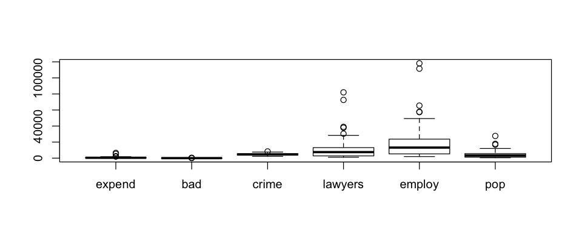

```r
options(repr.plot.width=8, repr.plot.height=3.25);boxplot(df[,2:7])
```

We identify multiple high outliers for both the covaritaes and the response, indicated by the circles within the boxplots.

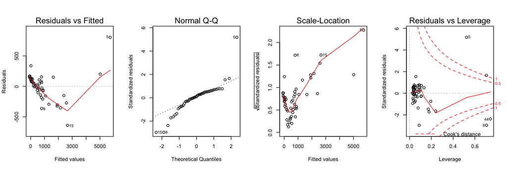

```r
model=lm(expend~bad+crime+lawyers+employ+pop, data=df)
options(repr.plot.width=10.5, repr.plot.height=3.5);par(mfrow=c(1,4));plot(model)
```

The plots give us an overview of the different values as well as the most extreme 3 values per plot. The observations of 5, 8, 15 and 44 are marked. Ordering the absolute values of the residuals, from smallest to largest, also gives us the numbers 5, 15 and 8 having the largest value. To further see if these leverage points are an influence point we can compute the Cook’s distances.

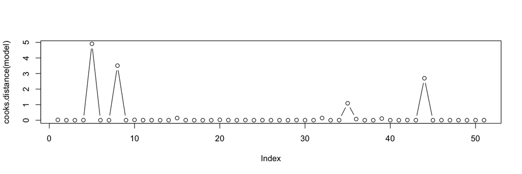

```r
plot(cooks.distance(model), type="b")
```

We can see the four deviating points clearly in the graph. For Cook’s distance we consider a datapoint influential when the distance is larger than 1, so in this case 5, 8, 35 and 44. We will remove these points from the data set as they potentially overshadow the “real” data that can provide us with more insights on general behaviour.

```r
df = df[-c(5,8,35,44),];attach(df)
```

a.2.1) - Colinearity

A matrix: 6 × 6 of type dbl

|  | expend | bad | crime | lawyers | employ | pop |
| --- | --- | --- | --- | --- | --- | --- |
| expend | 1.00 | 0.91 | 0.35 | 0.96 | 0.98 | 0.96 |
| bad | 0.91 | 1.00 | 0.33 | 0.86 | 0.91 | 0.91 |
| crime | 0.35 | 0.33 | 1.00 | 0.25 | 0.26 | 0.19 |
| lawyers | 0.96 | 0.86 | 0.25 | 1.00 | 0.97 | 0.95 |
| employ | 0.98 | 0.91 | 0.26 | 0.97 | 1.00 | 0.97 |
| pop | 0.96 | 0.91 | 0.19 | 0.95 | 0.97 | 1.00 |

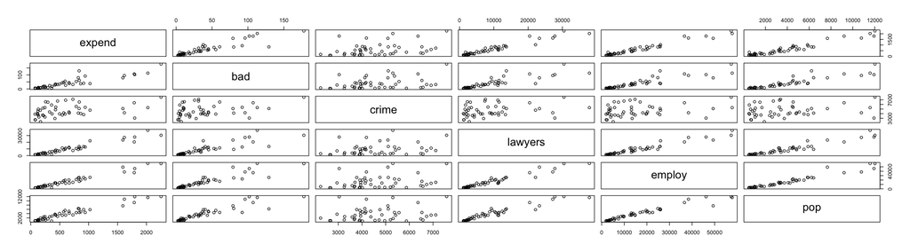

```r
options(repr.plot.width=18, repr.plot.height=5);
plot(df[,2:7]);
round(cor(df[,2:7]),2)
```

We identify collinearity in the covariate space. As can be seen in the graphs all seem to have collinearity except for the crime component. Also in the table the high correlation is confirmed with values (0.86:0.98) for all except for crime which has very low colinearity (0.19:0.35)